# Chapter 1: Using mixed models to look at pink salmon variation

Lia Domke

10/8/2020

# Mixed-effects models

The main hypothesis is that structured habitats or vegetated habitats are important structure for salmon in the nearshore. To test that using the NOAA dataset, I ran some simple glm and gam models by species to look at the main effect of habitat. However, in those model, I was not able to account for the sampling design that actually pairs habitat type within site.

Based on Schielzeth & Nakagawa (2012), I’ve determined that my main effect factor 1 is Habitat type and my main effect factor 2 is site. At 6 sites, I have a fully crossed sampling design where every habitat type (bedrock, kelp, and eelgrass) were sampled at each site.

By using mixed-effect model as a modelling framework with a fully crossed sampling design–this allows partitioning of variance between the four main sources of variances:

1. Main effect variance explained by factor 1
2. Main effect variance explained by factor 2
3. Interaction variance – variance in the response explainby combination of site x habitat **after controlling** for the average effect of the habitat acoss all sites and the average effect of the site on habitat type.
4. Residual variance – variance in the response unexplained by the habitat, site, and their interaction. If you *exclude* or *remove* the interaction term then the variance is POOLED in residual variance.

Important decision making points when fitting a mixed model. Determine which factors are fixed versus random is important. Including random factors should not be done lightly as it completely changes the interpretation of the model estimates. See the blog post and thread for more information on the difference between the two and when to use random effects [link](https://dynamicecology.wordpress.com/2015/11/04/is-it-a-fixed-or-random-effect/).

Based on advise from Franz’s course–when fitting mixed effect models and obtaining parameter estimations there are two main methods, Maximum Likelihood (ML) and Restricted Maximum Likelihood (REML). You **cannot** use REML to compare models with different fixed effects structure, rather ML is the best use for comparison of different models. After a “best” model is determiend, parameter estimation/CI using REML should be used.

## Model set up:

We selected 6 sites, with three habitat types that were each sampled once for salmon CPUE.

Questions:

1. What is the abundance of salmon in a typical habitat type
2. What is the variation of salmon among habitats (among group variance)
3. What is the variation of salmon within sites (within group variance)

yij = beta + bi + Eij

beta - mean abundance across habitats

bi - random variable representing the deviation from the population mean

bi ~ N(0, sigma-b^2)

Eij - random variable representing the deviation from observation j from the mean density for site

## Assumptions

- residuals are assumed to be independent, normally distributed random variables with **constant variance**
- random effects are assumed to be **independent** and normally distributed

## Model packages options

- nlme, functions : lme, nlme – can accommodate residual correlations
- lme4 - more stable algorithms, can fit generalized mixed effects models but does not accommodate residual correlation, functions: lmer, nlmer, glmer
- glmm - gmm using monte carlo likelihood estimation

```r
# quick look at the data were using
str(pink)
```

```
## 'data.frame':    28 obs. of  26 variables:
##  $ X          : int  1 2 3 4 5 6 7 8 9 10 ...
##  $ SiteID     : int  131 132 133 134 336 337 338 595 596 597 ...
##  $ EventID    : int  236 237 244 245 571 572 573 3168 3169 3170 ...
##  $ Date       : chr  "5/12/98" "5/12/98" "5/12/98" "5/12/98" ...
##  $ NEAR_DIST  : num  1072 1072 987 987 3586 ...
##  $ Locale     : chr  "Klawock Inlet" "Klawock Inlet" "Klawock Inlet" "Klawock Inlet" ...
##  $ SubLocale.y: chr  "" "" "" "" ...
##  $ Year       : int  1998 1998 1998 1998 1998 1998 1998 2007 2007 2007 ...
##  $ Temp       : num  10.5 10.5 9.9 9.9 NA NA NA 11 11 12 ...
##  $ Salinity   : int  30 30 24 25 NA NA NA 31 26 31 ...
##  $ Habitat    : chr  "Eelgrass" "Eelgrass" "Sand-gravel" "Sand-gravel" ...
##  $ Latitude   : num  55.6 55.6 55.6 55.6 55.5 ...
##  $ Longitude  : num  -133 -133 -133 -133 -133 ...
##  $ Gear       : chr  "BSEINE" "BSEINE" "BSEINE" "BSEINE" ...
##  $ Region     : chr  "southeastern Alaska" "southeastern Alaska" "southeastern Alaska" "southeastern Alaska" ...
##  $ Location   : chr  "Prince of Wales Island" "Prince of Wales Island" "Prince of Wales Island" "Prince of Wales Island" ...
##  $ SubLocale  : chr  "" "" "" "" ...
##  $ site_pair  : chr  "Klawock Inlet" "Klawock Inlet" "Klawock Inlet" "Klawock Inlet" ...
##  $ date       : chr  "1998-05-12" "1998-05-12" "1998-05-12" "1998-05-12" ...
##  $ julian     : int  132 132 132 132 134 134 135 164 164 164 ...
##  $ dist_km    : num  10.72 10.72 9.87 9.87 35.86 ...
##  $ Hab_type   : chr  "Vegetated" "Vegetated" "Unvegetated" "Unvegetated" ...
##  $ SpCode     : chr  "SALPINK" "SALPINK" "SALPINK" "SALPINK" ...
##  $ abundance  : int  5 9 3 18 10 0 2 0 0 770 ...
##  $ binomial   : int  1 1 1 1 1 0 1 0 0 1 ...
##  $ log_abund  : num  1.79 2.3 1.39 2.94 2.4 ...
```

```r
table(pink$site_pair) # observations at each site pair.
```

```
##
##  Ballena Island        Dall Bay Kah Shakes Cove   Klawock Inlet     Moira Sound
##               2               3               4               4               3
##      Nicols Bay     Reef Harbor  South Wadleigh  Sylburn Harbor
##               4               3               2               3
```

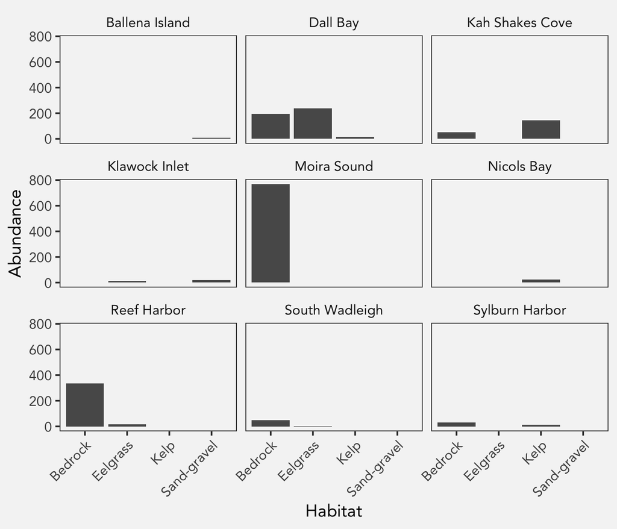

Figure 1: Pink salmon abundance per seine in different habitats at nine different sites

In figure 1 you can see that there are variable numbers of pink salmon caught at each site. Clearly the graph is dominated by the catch of almost 800 pink salmon at Moira Sound. In order to get a better idea, I’ll free up the y scale.

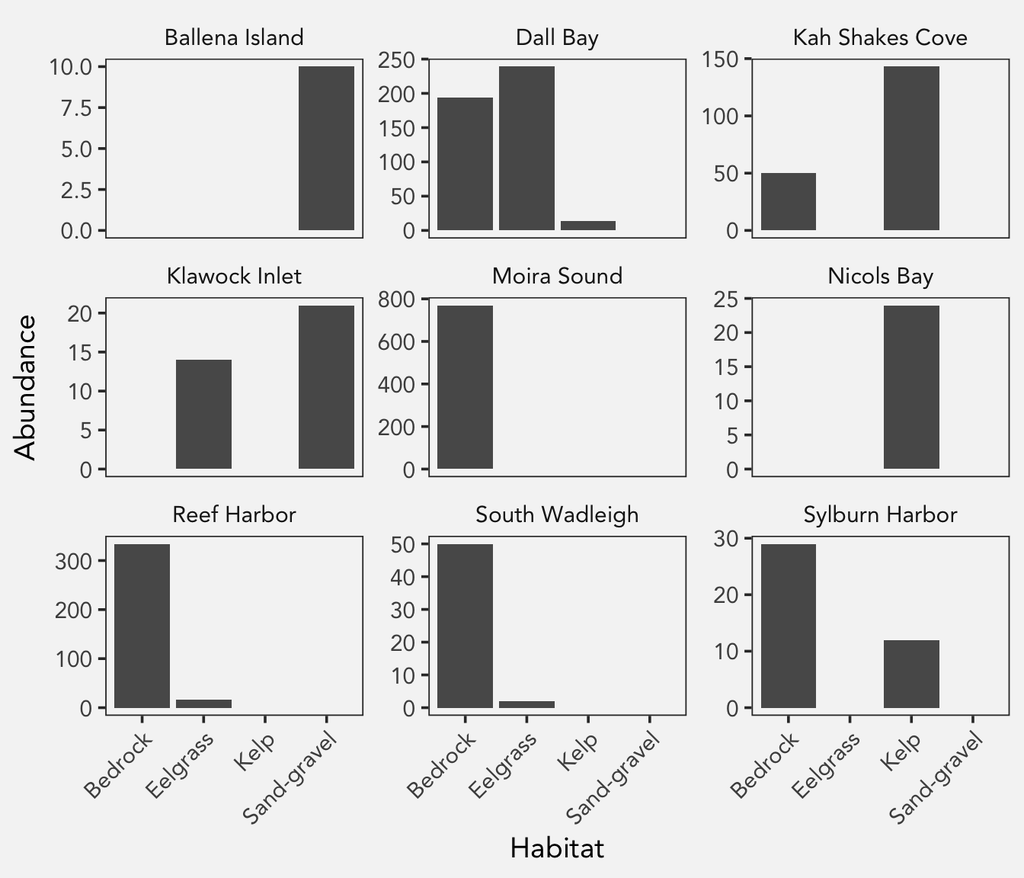

Figure 2: Pink salmon abundance per seine in different habitats at nine different sites with free y axis scale

Figure 2 shows that if you look at relative abundances at each site between habitat types, at 4 of the 9 sites more salmon were caught in bedrock over the other three habitats. Kelp and eelgrass had some salmon catch at different sites. However, clearly both sites and habitat are important is determining highly variable salmon abundances.

Want to use mixed models to account for site when looking at the influence of habitat type.

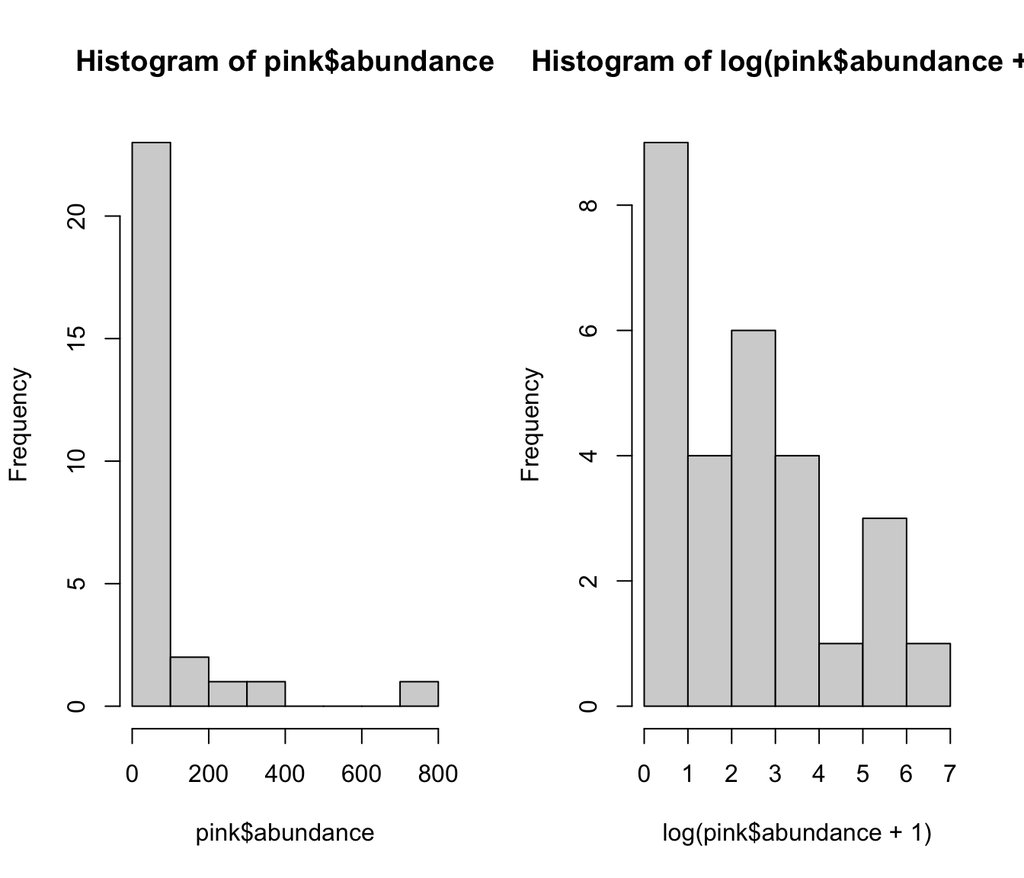

Figure 3: Histogram of the raw frequency of pink salmon and log transformed pink salmon caught overall at all sites and habitats

Likely need some sort of transformation to approximate normality, however, how strict is the normality assumption when implementing mixed models? Lets subset the data so that we’re looking at sites with complete observations to have a fully crossed design.

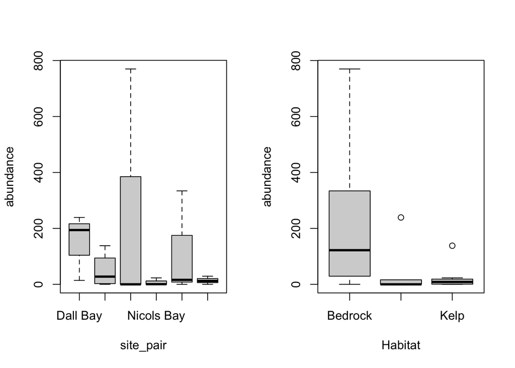

## LMER

Lets look at some different ways to write mixed models.

```r
mxd <- lmer(abundance ~ Habitat + (1 | site_pair), data = pink.sub)
```

```
## boundary (singular) fit: see ?isSingular
```

```r
# model doesn't fit well. because the fitted model is near singularity, however, I'm not sure what that means.
# indicates that the variances of one or more of the linear combinations of effects are close to (or actually) zero.
summary(mxd)
```

```
## Linear mixed model fit by REML ['lmerMod']
## Formula: abundance ~ Habitat + (1 | site_pair)
##    Data: pink.sub
##
## REML criterion at convergence: 228.5
##
## Scaled residuals:
##     Min      1Q  Median      3Q     Max
## -1.3501 -0.2500 -0.1419 -0.0463  3.1796
##
## Random effects:
##  Groups    Name        Variance Std.Dev.
##  site_pair (Intercept)     0      0
##  Residual              28896    170
## Number of obs: 20, groups:  site_pair, 6
##
## Fixed effects:
##                 Estimate Std. Error t value
## (Intercept)       229.50      69.40   3.307
## HabitatEelgrass  -187.00      98.14  -1.905
## HabitatKelp      -205.37      91.80  -2.237
##
## Correlation of Fixed Effects:
##             (Intr) HbttEl
## HabttElgrss -0.707
## HabitatKelp -0.756  0.535
## optimizer (nloptwrap) convergence code: 0 (OK)
## boundary (singular) fit: see ?isSingular
```

## lmLIST

```r
# lets try a diff package - lmList
# This fits the same fixed effect model **seperately** for each group (site?)
lmList_mxd <- lmList(abundance ~ Habitat | site_pair, data = pink.sub)
# Examin the parameter estimates (the coefficients from multiple linear regression) and the standard errors, t-statistic and p-value are testing the null hypothesis that the coefficients are equal to zero.
summary(lmList_mxd) # note that there doesn't seem to be enough info the generate a ttest
```

```
## Call:
##   Model: abundance ~ Habitat | NULL
##    Data: pink.sub
##
## Coefficients:
##    (Intercept)
##                      Estimate Std. Error       t value  Pr(>|t|)
## Dall Bay         1.940000e+02        NaN           NaN       NaN
## Kah Shakes Cove  5.000000e+01   67.40363  7.417998e-01 0.5354913
## Moira Sound      7.700000e+02        NaN           NaN       NaN
## Nicols Bay      -3.452129e-15   67.40363 -5.121576e-17 1.0000000
## Reef Harbor      3.340000e+02        NaN           NaN       NaN
## Sylburn Harbor   2.900000e+01        NaN           NaN       NaN
##    HabitatEelgrass
##                     Estimate Std. Error       t value  Pr(>|t|)
## Dall Bay         4.50000e+01        NaN           NaN       NaN
## Kah Shakes Cove -5.00000e+01   95.32313 -5.245316e-01 0.6522491
## Moira Sound     -7.70000e+02        NaN           NaN       NaN
## Nicols Bay       1.02558e-14   95.32313  1.075898e-16 1.0000000
## Reef Harbor     -3.18000e+02        NaN           NaN       NaN
## Sylburn Harbor  -2.90000e+01        NaN           NaN       NaN
##    HabitatKelp
##                 Estimate Std. Error   t value  Pr(>|t|)
## Dall Bay          -180.0        NaN       NaN       NaN
## Kah Shakes Cove     21.5   82.55226 0.2604411 0.8188859
## Moira Sound       -770.0        NaN       NaN       NaN
## Nicols Bay          12.0   82.55226 0.1453625 0.8977519
## Reef Harbor       -334.0        NaN       NaN       NaN
## Sylburn Harbor     -17.0        NaN       NaN       NaN
##
## Residual standard error: 67.40363 on 2 degrees of freedom
```

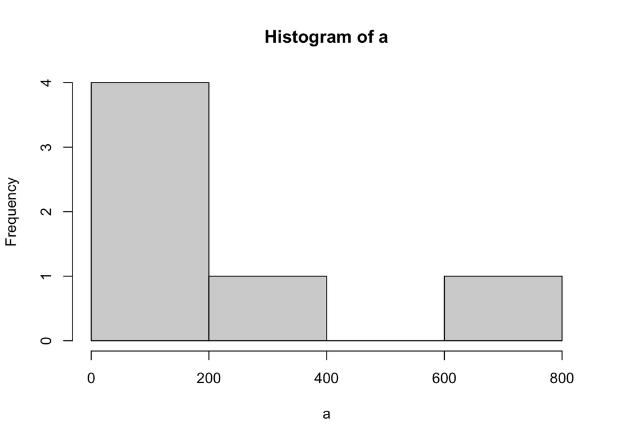

```r
par(mfrow=c(1,1))
a<-coef(lmList_mxd)$"(Intercept)"
hist(a) # the intercept parameters should be appox normally distributed in order to model site specific effects as random effects. This graph looks like its right skewed
```

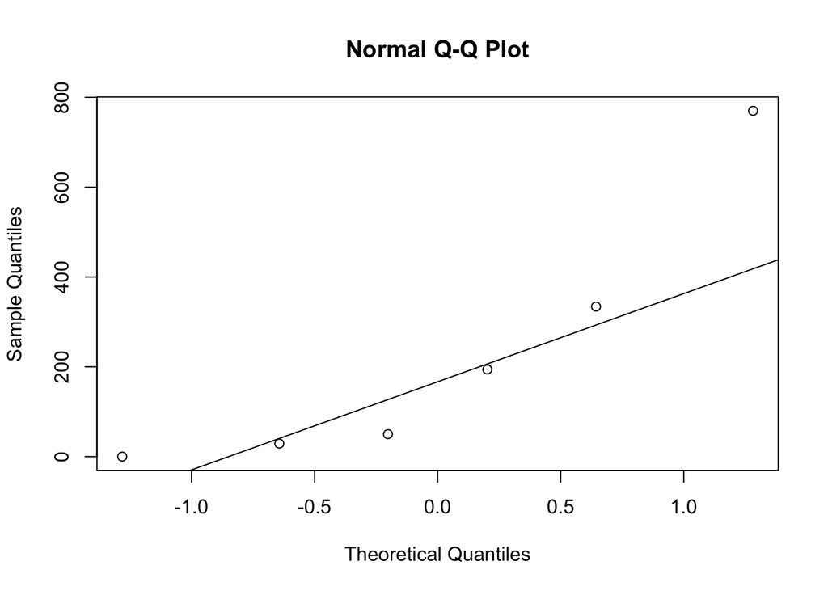

```r
qqnorm(a); qqline(a) # some spread, is this dataset too small to do this kind of model?
```

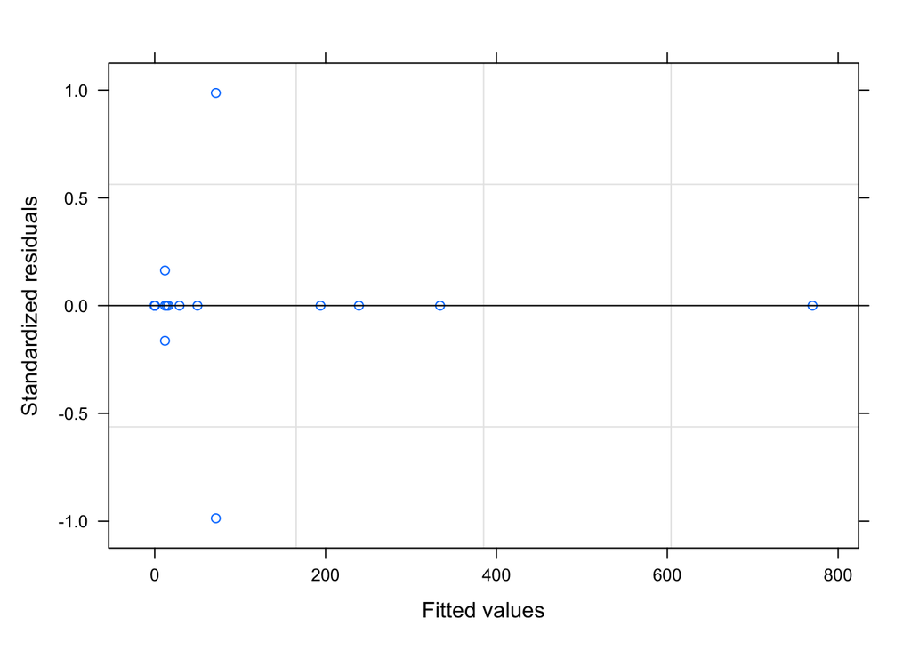

```r
plot(lmList_mxd) # residuals?
```

## NLME::LME

Based on Franz’s lectures from FISH 604, I’ve also tried using `nlme::lme`

```r
# First I'm going to fit the model using habitat as the fixed effect and site as the random. Because I'm only interested in this model and won't be doing model comparisons with different models, I'm going to fit the model using REML rather than ML.
mxd_pink <- lme(abundance ~ Habitat, data = pink, random = ~ 1 | site_pair,
method="REML")
```

Lets take a look at the summary table for this model.

```r
summary(mxd_pink)
```

```
## Linear mixed-effects model fit by REML
##   Data: pink
##        AIC      BIC    logLik
##   327.2585 334.3268 -157.6293
##
## Random effects:
##  Formula: ~1 | site_pair
##         (Intercept) Residual
## StdDev:  0.02464276 147.5589
##
## Fixed effects:  abundance ~ Habitat
##                        Value Std.Error DF   t-value p-value
## (Intercept)         203.8571  55.77203 16  3.655186  0.0021
## HabitatEelgrass    -176.7571  72.71783 16 -2.430726  0.0272
## HabitatKelp        -179.7321  76.36900 16 -2.353470  0.0317
## HabitatSand-gravel -193.5238 101.82534 16 -1.900547  0.0755
##  Correlation:
##                    (Intr) HbttEl HbttKl
## HabitatEelgrass    -0.767
## HabitatKelp        -0.730  0.560
## HabitatSand-gravel -0.548  0.420  0.400
##
## Standardized Within-Group Residuals:
##         Min          Q1         Med          Q3         Max
## -1.38153035 -0.18365541 -0.13968995 -0.03917925  3.83672377
##
## Number of Observations: 28
## Number of Groups: 9
```

Based on my conversations with Nicole, she said that the relative comparison of the random effect stdDev of intercept and residual are important. In her case the intercept residual was almost the same as the otterID (random) residual indicating that the OtterID plays almost the same role in determining carbon as season.

If we disregard this and continue to try and interpret the results. When looking at the fixed effects the mean value of bedrock (indicated by intercept) is substantially greater than the mean values in the other habitats and appears significantly different. Might be worthwhile to look into pairwise comparisons potentially using tukey’s test.

My other question is about this: Because this is a mixed model, aren’t you accounting for the variation in siteID in order to look at the effect of habitat? Does it really matter that the random effect residual is so high? And Where is the residual variation reported?

Lets test the role of habitat using an anova

```r
av <- anova(mxd_pink)
av
```

```
##             numDF denDF  F-value p-value
## (Intercept)     1    16 6.059234  0.0256
## Habitat         3    16 2.622332  0.0863
```

What does it mean that intercept is significant? At alpha 0.1, the group habitat is significant (p-value 0.0863015)

Lets look at the significants between habitats

```r
tv <- lsmeans(mxd_pink, pairwise~Habitat, adjust = "tukey")
tv
```

```
## $lsmeans
##  Habitat     lsmean   SE df lower.CL upper.CL
##  Bedrock      203.9 55.8  8     75.2      332
##  Eelgrass      27.1 46.7  8    -80.5      135
##  Kelp          24.1 52.2  8    -96.2      144
##  Sand-gravel   10.3 85.2  8   -186.1      207
##
## Degrees-of-freedom method: containment
## Confidence level used: 0.95
##
## $contrasts
##  contrast                 estimate    SE df t.ratio p.value
##  Bedrock - Eelgrass         176.76  72.7 16   2.431  0.1110
##  Bedrock - Kelp             179.73  76.4 16   2.353  0.1272
##  Bedrock - (Sand-gravel)    193.52 101.8 16   1.901  0.2666
##  Eelgrass - Kelp              2.98  70.0 16   0.043  1.0000
##  Eelgrass - (Sand-gravel)    16.77  97.1 16   0.173  0.9981
##  Kelp - (Sand-gravel)        13.79  99.9 16   0.138  0.9990
##
## Degrees-of-freedom method: containment
## P value adjustment: tukey method for comparing a family of 4 estimates
```

Although it does look liek the role of habitat can be important there are no significant differences between habitats for pink salmon abundances.

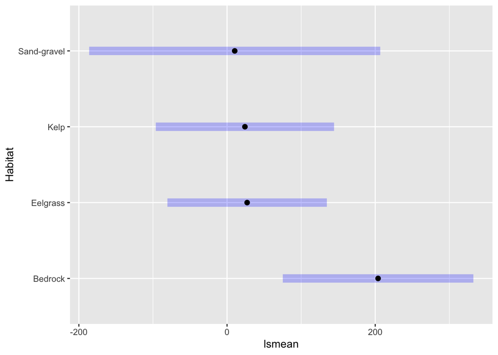

```r
plot(tv$lsmeans)
```

```r
mxd_v.unv <- lme(abundance ~ Hab_type, data = pink,
                     random = ~1 | site_pair, method = "REML")
```

```r
summary(mxd_v.unv)
```

```
## Linear mixed-effects model fit by REML
##   Data: pink
##        AIC      BIC    logLik
##   348.2069 353.2393 -170.1035
##
## Random effects:
##  Formula: ~1 | site_pair
##         (Intercept) Residual
## StdDev:    29.70055 149.3113
##
## Fixed effects:  abundance ~ Hab_type
##                       Value Std.Error DF   t-value p-value
## (Intercept)        146.8590  48.31375 18  3.039694  0.0070
## Hab_typeVegetated -121.2201  59.02912 18 -2.053565  0.0548
##  Correlation:
##                   (Intr)
## Hab_typeVegetated -0.784
##
## Standardized Within-Group Residuals:
##        Min         Q1        Med         Q3        Max
## -0.9378686 -0.3851630 -0.1314977 -0.0507197  4.0379688
##
## Number of Observations: 28
## Number of Groups: 9
```

Well similar story here, the random effects residuals are still substantially larger than the intercept–which is questionable.

Lets look at an anova

```r
av2 <- anova(mxd_v.unv)
av2
```

```
##             numDF denDF  F-value p-value
## (Intercept)     1    18 5.304971  0.0334
## Hab_type        1    18 4.217129  0.0548
```

Habitat is significant at alpha = 0.1 (p-value 0.0548399)

Lets look at the significants between habitats

```r
tv2 <- lsmeans(mxd_v.unv, pairwise~Hab_type, adjust = "tukey")
tv2
```

```
## $lsmeans
##  Hab_type    lsmean   SE df lower.CL upper.CL
##  Unvegetated  146.9 48.3  8     35.4      258
##  Vegetated     25.6 36.7  8    -59.0      110
##
## Degrees-of-freedom method: containment
## Confidence level used: 0.95
##
## $contrasts
##  contrast                estimate SE df t.ratio p.value
##  Unvegetated - Vegetated      121 59 18   2.054  0.0548
##
## Degrees-of-freedom method: containment
```

Oh duh. Its the same I think. Cause theres only two levels of the main effects factor 1

```
## I bet you wanted to call this with just object[[1]] - use '[[]]' or which' if I'm wrong.
## See '? emm_list' for more information
```

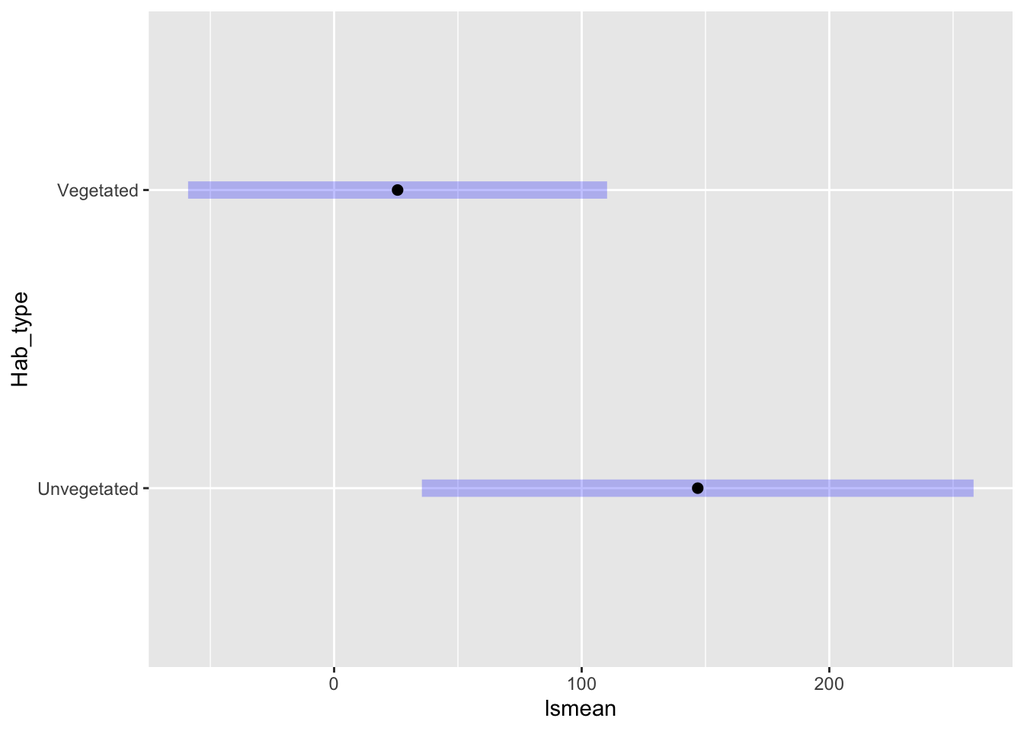

```r
plot(tv2)
```

CI overlab for different habitat types veg and unvegetated.